# A1 — instructor solutions

Simulated iPhone reception evidence brief

Author

ETX1100 / ETX5900

This key answers the current A1 brief using the simulated assignment data. It is a worked example, not a claim about real Apple customers or handsets. Alternative charts and wording can be correct if the denominators, methods and limitations are clear.

Download the worked Excel solution workbook. It includes the source records, formulas, reference results, charts and a sample media recommendation.

## 1. Describe the evidence — 20 marks

**Solution**Solution 1**

**Units and target populations.** In `Customer survey`, each row is one original purchaser, including purchasers who later returned the phone. The population of interest is purchasers on the fictional company customer list for each model; the stated sample is 2,000 randomly selected purchasers per model. `customer_id` is an identifier; `model`, `coverage`, `case_used`, `call_dropped`, `reported_issue`, and `returned` are categorical. The last three are distinct binary outcomes. The observed call and 30-day support/return records have different observation windows.

In `Reception tests`, each row is one distinct sampled handset. The population of interest is handsets in the fictional production batches; the stated sample is 100 per model. `handset_id` is an identifier, `model` is categorical, and both signal readings and calculated loss are numerical measurements in dBm or dB. For each handset, `loss = ungripped_dbm − gripped_dbm`; the readings are paired **within** handset. The 3 dB test uses only the 100 iPhone 4 handset losses. The survey addresses purchaser experiences and behaviours; the lab tests address handset measurements under standardised conditions.

**CEO evidence panel.** Denominators for the first three rates are 2,000 sampled purchasers **within each model**; loss summaries use 100 tested handsets per model.

| Measure | iPhone 3GS | iPhone 4 |
| --- | --- | --- |
| Survey purchasers | 2,000 | 2,000 |
| Observed call dropped | 108 / 2,000 = **5.4%** | 120 / 2,000 = **6.0%** |
| Support issue in prior 30 days | 8 / 2,000 = **0.40%** | 11 / 2,000 = **0.55%** |
| Returned in 30 days, any reason | 120 / 2,000 = **6.0%** | 34 / 2,000 = **1.7%** |
| Tested handsets | 100 | 100 |
| Mean loss (dB) | **2.584** | **2.791** |
| SD loss (dB) | 1.247 | 1.313 |
| Median loss (dB) | 2.40 | 2.65 |

**Solution**Solution 2**

The middle 50% of measured loss is **1.900–3.425 dB** for 3GS and **1.900–3.525 dB** for iPhone 4. Both sample means are below 3 dB, although some individual handsets have losses above that value. A chart of the customer outcome and a distribution chart of loss are below; the workbook includes the same briefing charts and their underlying data.

**Critique.** Call-drop rates and measured loss address the public reception concern more directly than low support-contact or return rates. A support report requires a customer to contact the company; it is not the same event as a dropped call. Returns are for **any reason**, so the 1.7% iPhone 4 return rate is not a reception-related return rate. A reassuring panel that shows only support reports or returns would conceal the slightly higher observed call-drop rate and the measured reception losses. One observed call per person may not represent that owner’s usual experience; coverage, case use and willingness to report also affect measurement. The production-batch test may not reproduce every real-world network condition.

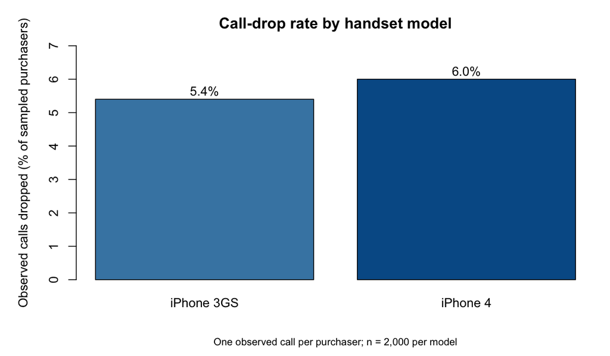

Observed call-drop rate by model; one call per purchaser.

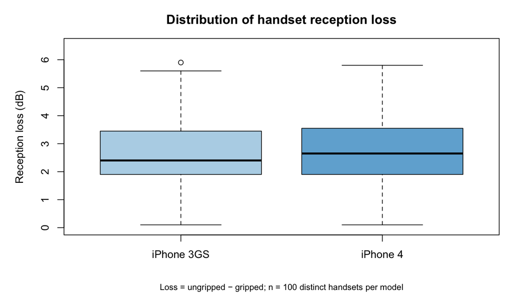

Distribution of reception loss for 100 handsets of each model.

## 2. Probability and reported issues — 20 marks

**Solution**Solution 3**

The auditable `model × call_dropped` table is:

| Model | No drop | Dropped | Total | Dropped within model |
| --- | --- | --- | --- | --- |
| iPhone 3GS | 1,892 | 108 | 2,000 | 5.4% |
| iPhone 4 | 1,880 | 120 | 2,000 | 6.0% |
| **Total** | **3,772** | **228** | **4,000** | **5.7%** |

| Requested probability | Working | Estimate | Denominator |
| --- | --- | --- | --- |
| $P(\text{drop}\mid\text{iPhone 4})$ | $120/2{,}000$ | **6.00%** | iPhone 4 owners |
| $P(\text{iPhone 4 and drop})$ | $120/4{,}000$ | **3.00%** | all owners in the deliberately balanced sample |
| $P(\text{report}\mid\text{drop})$ | $4/228$ | **1.754%** | owners whose observed call dropped |
| $P(\text{drop or report})$ | $(228+19-4)/4{,}000$ | **6.075%** | all owners in the balanced sample |

**Solution**Solution 4**

The overlap count is **4** owners who both experienced a dropped observed call and reported an issue. The union subtracts that overlap once. In Excel, `COUNTIFS` can reproduce each intersection; the workbook’s `Contingency` and `Probabilities` sheets show the formulas.

The conditional drop rate is **6.0%** for iPhone 4 versus **5.4%** for 3GS, a difference of **0.6 percentage points** in these samples. The comparison is descriptive. Coverage, case use, network conditions and other differences could affect the observed call, so it does not by itself identify the handset model as the cause. Because the survey contains equal numbers from each model by design, a pooled 4,000-record probability does not estimate the actual market mix of the models.

## 3. Estimate uncertainty — 20 marks

**Solution**Solution 5**

**iPhone 4 issue-report proportion.** There are $x=11$ reports among $n=2{,}000$ owners, giving $\hat p=11/2000=0.0055$ or **0.55%**. The ordinary large-sample interval used in Weeks 3–4 has

$$SE(\hat p)=\sqrt{\frac{\hat p(1-\hat p)}{n}}=0.001654,$$

$$\hat p\pm1.96SE=0.0055\pm0.003241=\boxed{[0.002259,\ 0.008741]},$$

or **[0.226%, 0.874%]**. The sample 3GS rate is $8/2000=\mathbf{0.40\%}$, a descriptive comparison rather than a formal difference test. Under the stated random sampling from the fictional customer list and accurate record linkage, the procedure gives a 95% confidence interval for the population proportion of iPhone 4 purchasers who reported an issue in the prior 30 days. The success/failure counts are 11 and 1,989; the small success count makes the Normal approximation less robust than it would be for a common event. The interval concerns **support reporting**, not all reception problems.

**iPhone 4 mean handset loss.** With $n=100$, $\bar x=2.791$ dB and $s=1.3126$ dB, $SE=s/\sqrt n=0.13126$ dB. Using $t_{0.975,99}=1.9842$ gives

$$2.791\pm1.9842(0.13126)=\boxed{[2.531,\ 3.051]\text{ dB}}.$$

This is a 95% interval for the mean loss among handsets in the fictional test population, assuming an appropriate random sample and a reasonable sampling distribution of the mean. It is not a range for 95% of individual handsets.

The stated sample sizes reduce **random** uncertainty, but they do not repair a narrow customer list, non-response, record errors, or lab conditions that differ from real use. The two datasets have different target populations and cannot be pooled into one interval.

## 4. Test the mean reception-loss claim — 25 marks

**Solution**Solution 6**

Let $\mu_4$ be the fictional iPhone 4 production-batch mean reception loss in dB. Test $H_0:\mu_4\le3$ against $H_1:\mu_4>3$ at $\alpha=0.05$. Calculate the statistic at the null boundary $\mu_0=3$ dB. This is a **one-sample, right-sided t test** of the iPhone 4 handset losses. The ungripped and gripped readings on each handset are reduced to one loss value before testing. The separate 3GS sample is relevant to the descriptive panel, but it is not part of this test.

| Quantity | iPhone 4 handset sample |
| --- | --- |
| $n$ | 100 |
| Sample mean loss (dB) | 2.791 |
| Sample SD loss (dB) | 1.3126 |
| Standard error (dB) | 0.13126 |
| Decision threshold (dB) | 3 |

**Solution**Solution 7**

From the 100 iPhone 4 losses, $SE=s/\sqrt n=1.3126/\sqrt{100}=0.13126$ dB. The statistic is

$$t=\frac{\bar x-\mu_0}{s/\sqrt n}
=\frac{2.791-3}{0.13126}
=\mathbf{-1.592},\qquad df=99.$$

The right-tail p-value is `=T.DIST(1.592293,99,TRUE)`, approximately **0.943**. The t distribution is symmetric, so the left-tail area at $-t$ equals the right-tail area at $t$; the worksheet formula `=T.DIST(-t_cell,df_cell,TRUE)` works for either sign. **Fail to reject $H_0$** at 5%: this sample does not provide evidence that the iPhone 4 population mean reception loss exceeds 3 dB. It also does not prove that the population mean is at or below 3 dB.

The observed iPhone 4 mean is **0.209 dB below the threshold**; a one-sided 95% lower confidence bound is about **2.573 dB**. That lower bound does not establish that the mean exceeds 3 dB. The two-sided 95% interval in Part 3 includes 3 dB, showing why the observed sample mean alone is insufficient to settle whether the population mean is below the threshold. The observed 3GS mean is **2.584 dB** and the descriptive sample mean gap is **0.207 dB**, but this one-sample test gives **no inferential conclusion about a difference between models**. A Type I error would be concluding that the iPhone 4 population mean exceeds 3 dB when it is actually at or below 3 dB.

## 5. Advise Corporate Affairs and PR — 15 marks

**Solution**Solution 8**

The following sample recommendation uses two precise supported claims, includes contrary evidence, and identifies a claim to avoid.

> We take the reception concern seriously and will publish the results of further testing. In our simulated survey, 6.0% of observed calls dropped among iPhone 4 purchasers, compared with 5.4% for iPhone 3GS purchasers. The new model did slightly worse on this observed customer measure. Support reports were uncommon—0.55% for iPhone 4 and 0.40% for iPhone 3GS—but a low support-contact rate does not mean calls did not drop. All-cause returns were 1.7% and 6.0%, respectively; the data do not identify which returns were due to reception. In separate handset tests, average reception loss was 2.79 dB for iPhone 4 and 2.58 dB for iPhone 3GS. Both sample means were below our 3 dB decision threshold. The one-sided test does not provide evidence that the iPhone 4 population mean exceeds 3 dB (p = 0.943), but it cannot prove that mean is below 3 dB. This test does not establish a difference between the models. The CEO should avoid claiming that iPhone 4 has no reception problem or that the lower return rate proves customers are satisfied. These samples cannot explain every dropped call or predict performance in all network conditions. We recommend publishing the methods, testing more handsets and real-world call conditions, and reporting results and corrective action promptly.

The CEO’s opening should acknowledge the concern before quoting reassuring figures. Any public version must make clear that this is a **fictional teaching case**, if shared outside the assignment context.